# Nback

Author

Rena Katsumata

## 1. 目的 (Introduction)

本研究では、ワーキングメモリについて検討する。

**背景**

ワーキングメモリとは、目的に合わせて情報を一時的に覚えながら、同時に頭の中で整理や処理を行う脳の機能（作業記憶・作動記憶）のこと（(Owen et al. 2005)）。

**目的** 実験では、人間の**作業記憶（ワーキングメモリ）の容量**および、提示される情報を逐一更新していく情報更新機能（アップデート機能）のメカニズムを明らかにすることを目的とした。特に、Nの数（負荷の高さ）を変化させることで、認知負荷が作業記憶のパフォーマンスや脳の活動に与える影響を検証する。

## 2. 方法 (Method)

### 参加者

学生約10名のデータを収集した。

### 装置と材料

実験プログラムはGitHub Pagesを用いて作成し、公開した。  
参加者は、各自のスマートフォンまたはPCのブラウザから参加した。

### 手続き

ディスプレイの中央に注視点（例：`+`）を**500ミリ秒**提示した後、一連の刺激（アルファベット、数字、または位置など）が1つずつ順次提示された（各刺激の提示時間は**500ミリ秒**、刺激間のインターバル（ISI）は**1000ミリ秒**）。参加者は、現在画面に提示されている刺激が、$N$個前（例：2-backであれば2つ前）**に提示された刺激と「同じ」であるか「異なる」かを判断し、それぞれに対応するキーを速やかに入力することが求められた。試行間隔（ITI）は**2000ミリ秒とした。

## 3. 結果 (Results)

N-Back課題における1-Back条件と2-Back条件の間のパフォーマンスの違いを検討するため、対応のあるt検定を行った。その結果、両条件間に統計的に有意な差は認められなかった（$t(9) = -0.50, p = .632$）。したがって、ワーキングメモリ負荷（1-Back条件 vs 2-Back条件）の間で、従属変数に明確な差は確認されなかった。

```
[1] "--- 記述統計量 ---"
```

```
# A tibble: 2 × 5
  condition mean_accuracy sd_accuracy     n     se
  <chr>             <dbl>       <dbl> <int>  <dbl>
1 1-back            0.287      0.0374    11 0.0113
2 2-back            0.291      0.0447    10 0.0141
```

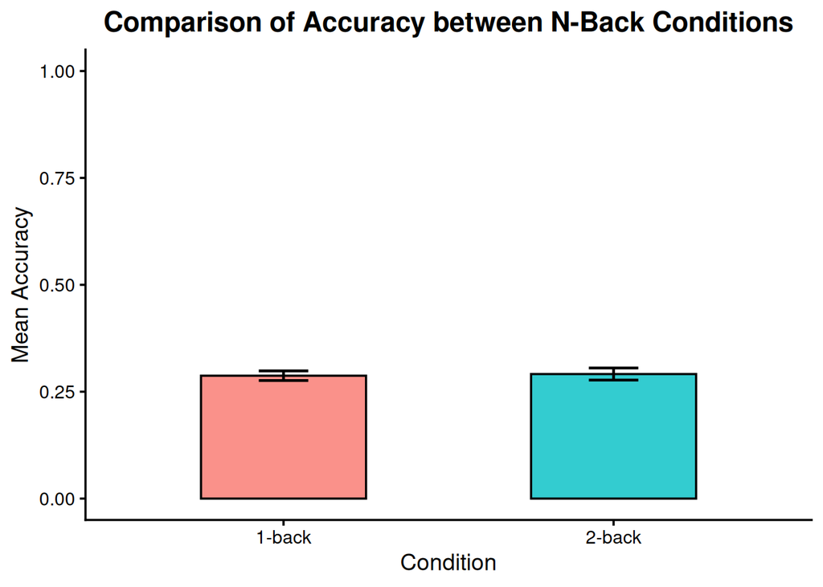

```
[1] "--- 記述統計量（平均と標準偏差） ---"
```

```
# A tibble: 2 × 4
  condition mean_accuracy sd_accuracy     n
  <chr>             <dbl>       <dbl> <int>
1 1-back            0.287      0.0374    11
2 2-back            0.291      0.0447    10
```

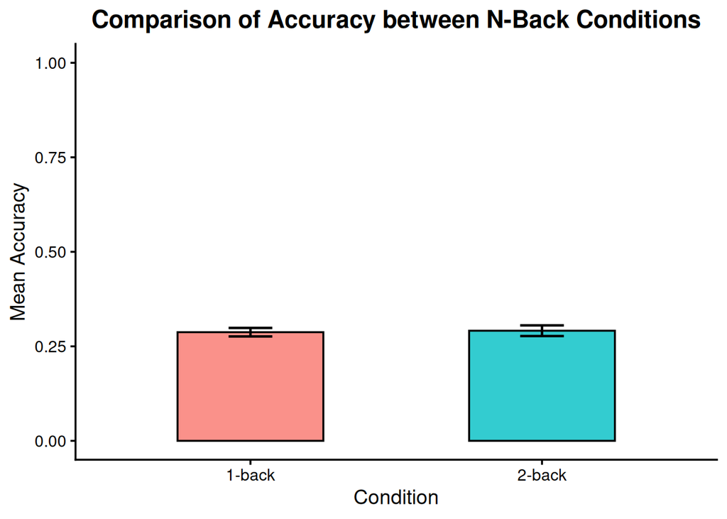

## 4. 考察 (Discussion)

本研究の限界としては、参加者が特定の集団に偏っていたことや、試行回数が限られていたことが挙げられる。今後は、異なる対象層との比較を行ったり、刺激の種類を変更したりして、作業記憶のメカニズムをより多角的に検証していく必要がある。

## 5. 引用文献 (References)

Owen, Adrian M., Kathryn M. McMillan, Angela R. Laird, and Ed Bullmore. 2005. “N-Back Working Memory Paradigm: A Meta-Analysis of Normative Functional Neuroimaging Studies.” *Human Brain Mapping* 25 (1): 46–59. https://doi.org/10.1002/hbm.20131.